# Community Structure and Barnacle Settlement on Coil Oil Point Reserve is Linked to Intertidal Zone and Substrate Type

Nathalie Bonnet

2024-11-21

### Abstract

Barnacle settlement in a marine intertidal zone is informative of the population dynamics and abiotic forces contributing to recrutiment patterns. In our study we sought to understand the community structure between upper and lower intertidal zones on a Santa Barbara intertidal ecosystem, and the factors that determine barnacle settlement. We conducted a field study using quadrats to estimate the percent cover of organisms and substrate types, and used a factorial design experiment to test barnacle settlement on smooth and rough substrate between intertidal zones. Invertebrate abundance was highest in the low tide zone, and barnacle recruitment was significantly higher on rough substrate in the lower intertidal zone. Our results contribute to our understanding of dirtribution patterns by broadcast spawning organisms in environments with various types of settlement surface and intertidal conditions. This information will be critical to predicting habitable species ranges as sea levels rise and temperate environments experience warming effects.

### Introduction

Rocky intertidal communities support diverse populations of plants and animals, and act as a connection between other ecosystems by supporting sea birds, marine mammals, and terrestrial consumers. Intertidal areas typically show distinctive vertical zonation patterns determined by biotic and abiotic forces. These vertical zones are typically defined as the supratidal, high tidal, middle tidal, and low tidal zones (McNeill 2010). Each vertical zone experiences unique abiotic and biotic stressors that determine unique community structure. The distribution patterns of barnacles (Chthamalus spp.) and other sessile invertebrates are of interest in these ecosystems due to their tolerance of the extreme conditions imposed by changing tides and sun exposure. Barnacles provide important 3D structure that creates micro habitats and breeding grounds for other organisms (Barnes 2000). Their settlement patterns are complex, and rely on several factors. Abiotic conditions that impose desiccation and heat stress on organisms in the intertidal community determine the upper limit of settlement, while the lower limit is largely set by competition for space with other barnacles and predation pressure (Connell 1961). Juvenile recruits also rely on the presence of adult barnacles for settlement cues (Raimondi 1988 and Chabot, and Bourget 1988), and as broadcast spawners, juvenile recruitment is also dependent on internal wave forces and onshore winds (Valencia-Gasti and Ladah 2016). The heterogeneity of substrate available for settlement provides refuges for barnacle recruits, and in a previous study of settlement in natural and artificial crevices, barnacles preferentially settled more in small protected crevices and not on horizontal surfaces. While this study determined that surface heterogeneity was significant in barnacle settlement, they did not achieve significant results in an experiment using artificial substrate, as barnacles preferentially settled on natural substrate (Chabot and Bourget 1988). In our study, we sought to characterize the community in a Southern California intertidal ecosystem, and evaluate how barnacle recruitment is affected by experimental substrate treatments and intertidal zone. We hypothesized that where algae is less exposed to desiccation pressure, it is more abundant, and thus will be more abundant in the low intertidal zone. We predicted that invertebrate populations would be more abundant in the low zone based on these physical forces and more nutrient availability. Based on the same abiotic forcing, we further hypothesized that barnacle recruitment would be highest in the low intertidal zone.

### Methods

To characterize the community zonation patterns in an intertidal area in Santa Barbara, we conducted a field survey at Coil Oil Point Reserve (COPR) in Santa Barbara, CA (34.4081°N, 119.8780°W). COPR is a coastal strand ecosystem made up of shoreline, estuarine habitats, coastal dunes, and scrub land. Our study site was a rocky sand stretch of shoreline on the beach point between Sands Beach and Devereaux Beach (Fig. 1). Based on the Central California intertidal ecosystem, we expected to see green and red algae, including Ulva and Corallina species. Commonly observed invertebrates are limpets, mussels, barnacles (Chthamalus spp.), and anemones (Anthopleura spp). Additionally, snail species such as Nucella and Littorina were anticipated.

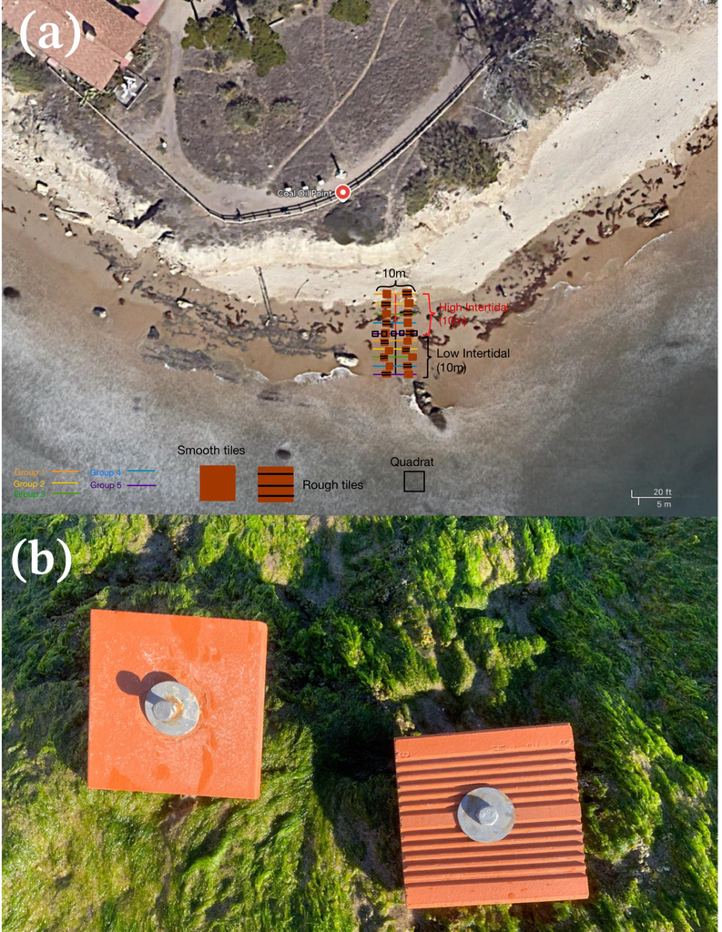

Figure 1. Contextual images for the Coil Oil Point site location and experimental setup. (a) Shows the 20 m transect line running perpendicular to the shoreline split into high and low tide zones. The locations of each 10 m group transect on the main 20m transect are shown. The approximate locations of the rough and smooth tiles drilled down are shown, and an example of the quadrat layout for one group transect is shown. (b) is a photo from the site of a smooth tile (left) and a rough tile (right).

On November 5, 2024, we conducted field observations using 27cmx27cm quadrats. On the day of observations, the tide was falling at 3.1 feet at 2:30 pm, with low tide at 0.1 feet and 6:33 pm. A 20 m transect line was laid perpendicular to the shoreline. 5 groups were spaced every 2 meters on the main transect line, and each group laid out a 10 meter transect parallel to the shoreline. Each group laid quadrats every 1 m along the parallel transect in both the upper (0m-10m) and lower (10m-20m) intertidal zones. The substrate type cover in each quadrat was estimated as percent cover out of 100. We only observed boulder, boulder/sand, and sand. Also in each quadrat, the percent cover by functional group was estimated as none (substrate), plant, algae, invertebrate, or other. 198 total functional group observations were recorded between the 2 tide zones.

These data were formatted in a csv file and analyzed in R (version 4.4.1 2024-06-14) and R Studio (version 2023.12.1 +402). To test our hypothesis that there would be greater percent cover of algae and invertebrates in the low tide zone, we calculated the mean cover of both functional group in each zone, and found the standard deviation and standard error to compare differences. To test our hypothesis that barnacle recruitment is higher in low tide zones and on rough substrate, we ran a 2 way analysis of variance (ANOVA) to assess if intertidal zone and substrate type significantly affect barnacle recruitment, as well as to assess if these variables had an interaction effect. Qualitative comparison of results was done by plotting bar graphs to visualize the distribution of functional groups and barnacle recruitment across intertidal zones.

### Results

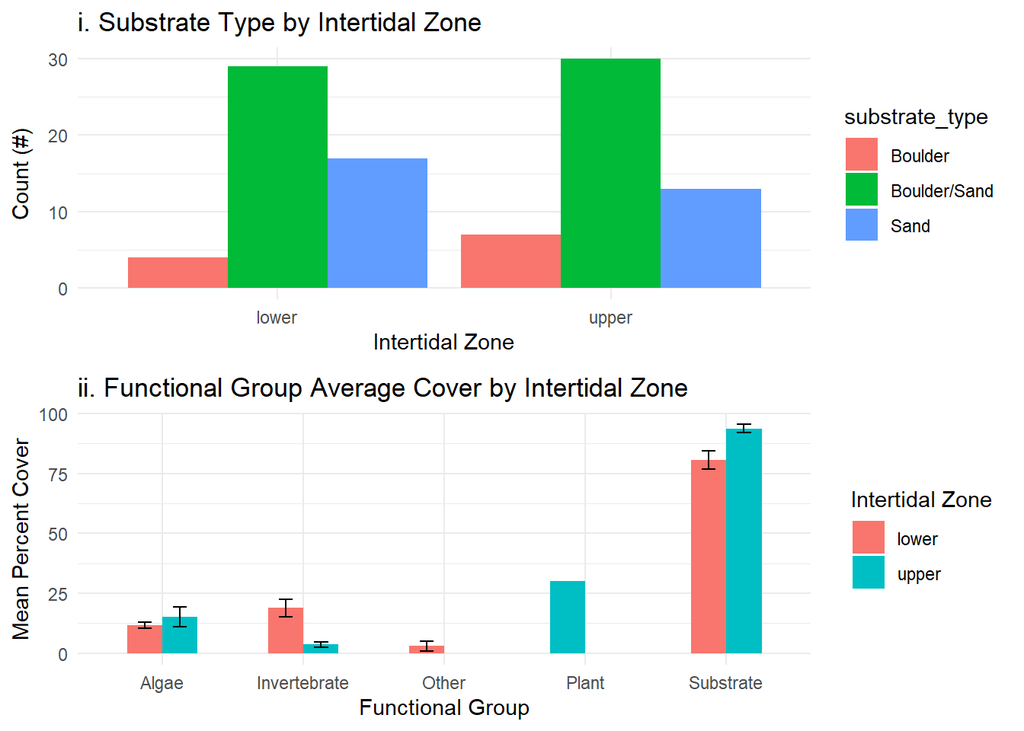

Figure 2: Multipanel plot results of substrate type cover and functional group cover between the lower and upper intertidal zones. Plot i. Is a bar graph showing the amount of substrate counted? by intertidal zone. Plot ii. Is a bar graph showing the mean percent cover.

The numerical difference in reported substrate type was not large enough to conclude any difference between low and upper intertidal zones,. The most commonly observed substrate type in both intertidal zones at COPR was boulder/sand, which represented boulders that were seen to be partly covered by sand. Sand alone was the next most common substrate type in both zones, with boulder alone being the least common.

```r
fakedf2 <- data.frame( Intertidal_Zone = c("Lower", "Lower", "Upper", "Upper", "Upper"),
  Functional_Group = c("Algae", "Invertebrate", "Algae", "Invertebrate", "Plant"),
  Mean_Percent_Cover = c(11.6, 19.3, 15.1, 3.58, 30.0),
  Standard_Deviation = c(7.23, 22.2, 16.4, 3.44, NA),
  Standard_Error = c(1.28, 3.68, 4.11, 0.996, NA))
flextable(fakedf2)%>%
  set_caption(caption="Table 1. Percent Cover of Functional Groups by Intertidal Zone")
```

Table 1. Percent Cover of Functional Groups by Intertidal Zone

| Intertidal_Zone | Functional_Group | Mean_Percent_Cover | Standard_Deviation | Standard_Error |
| --- | --- | --- | --- | --- |
| Lower | Algae | 11.60 | 7.23 | 1.280 |
| Lower | Invertebrate | 19.30 | 22.20 | 3.680 |
| Upper | Algae | 15.10 | 16.40 | 4.110 |
| Upper | Invertebrate | 3.58 | 3.44 | 0.996 |
| Upper | Plant | 30.00 |  |  |

Table 1: table displaying the mean percent cover for the functional groups “Algae” “Invertebrate”, and “Plant” in the upper and lower intertidal zones. The table includes the standard deviation and standard error of all observations excluding plants.

In our observations of barnacle recruitment, it was clear that barnacles recruited better onto rough tiles than on smooth tiles. Further, the lower intertidal zone showed much greater barnacle recruitment.

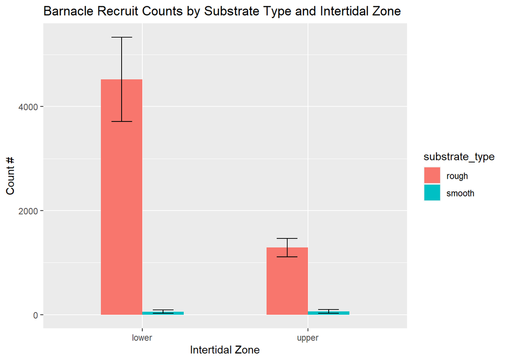

Figure 3: Bar graph displaying the barnacle recruitment counts for rough and smooth tiles in both intertidal zones. Includes error bars representing standard error.

```r
flextable(summary_settlement)%>%
  set_caption(caption="Table 2. Mean Recruitment of Barnacles by Tile Type and Intertidal Zone.")
```

Table 2. Mean Recruitment of Barnacles by Tile Type and Intertidal Zone.

| tide_zone | substrate_type | count_avg | count_sd | count_se |
| --- | --- | --- | --- | --- |
| lower | rough | 4,525.33333 | 1,987.16790 | 811.25790 |
| lower | smooth | 57.50000 | 85.74789 | 35.00643 |
| upper | rough | 1,290.00000 | 433.18172 | 176.84570 |
| upper | smooth | 58.33333 | 88.36440 | 36.07461 |

Table 2: table displaying the average count of barnacle recruits by tile type and intertidal zone, including the count standard deviation and count standard error.

Barnacle recruitment was low on smooth tiles in both the low and upper intertidal. For the smooth tiles in the high zone, mean count was 58 ± 36, and in the low smooth tile count averaged 57 ± 35. In the upper intertidal, recruitment was still relatively low on the rough tiles, averaging 1,290 ± 176, compared to the high recruitment average on rough tiles in the low intertidal (4,525 ± 811).

To analyze if recruitment is significantly affected by intertidal zone and substrate type, a 2 way ANOVA was run. The relationship between tide zone and recruitment count had 1 degree of freedom, with F= 15.12, and P=0.0009. Since p<0.05, we reject the null hypothesis that zone is not a significant factor in recruitment count , and determine that barnacle recruitment on our experimental tiles is dependent on the intertidal zone where they were placed.

The relationship between barnacle count and tile type was also significant, with 1 degree of freedom, F= 46.95, and P= 1.17e-06. Since p<0.05, we determined that the tile surface is a significant factor in barnacle recruitment.

When analyzing both tide zone and substrate type, the two factors have an interaction effect on recruitment. With 1 degree of freedom, F= 15.13, and P= 0.0009, since p<0.05, we can say that the effect of one factor relies on the effect of the other. The magnitude of the effect of substrate type relied on the effect of the intertidal zone, so the effect on settlement was most greatly influenced by rough substrate in the low intertidal zone.

```r
anova_substrate_zone <- aov(count~tide_zone *substrate_type, data = settlement_data)

summary(anova_substrate_zone)
```

```
##                          Df   Sum Sq  Mean Sq F value   Pr(>F)
## tide_zone                 1 15692985 15692985   15.12 0.000913 ***
## substrate_type            1 48726450 48726450   46.95 1.17e-06 ***
## tide_zone:substrate_type  1 15709162 15709162   15.13 0.000909 ***
## Residuals                20 20758218  1037911
## ---
## Signif. codes:  0 '***' 0.001 '**' 0.01 '*' 0.05 '.' 0.1 ' ' 1
```

### Discussion

We conducted this study to characterize the intertidal communities on Coal Oil Point in Goleta, CA by identifying the species composition and abundance between high and low intertidal zones, and to understand how barnacle settlement is affected by substrate type and intertidal zonation.

An unexpected result of our study was that algae species were more abundant in the high intertidal zone than the low. As lower intertidal species experience longer submersion times, they have a longer time to uptake nutrients in the water column to utilize for biomass. A species of brown algae submerged for 10 hours in a 12 hour tidal period can take up over 3 times the amount of phosphorus as a species submerged for 1 hour (Hurd and Dring 1990). Thus, we anticipated higher percent cover in the low intertidal zone. Although the magnitude of difference for algae cover was low, differences in algae abundance can largely be explained by seasonal variation in growth and herbivory. A study on the Oregon coast demonstrated that grazing by limpets alone reduces algae cover year round by an average of around 50% (Cubit 1984). Limpets are limited to what we have described to be the low intertidal zone for the purposes of our study due to their low thermal tolerance and rapid dehydration (Wolcott 1973). Limpets were grouped into our functional group “Invertebrates”, along with barnacles and other sessile invertebrates, mussels, and mobile invertebrates like Echinoderms and Cnidarians. These organisms experience the same kind of biotic forcing as limpets, and are generally found in lower intertidal areas. Our study of invertebrate cover reflects this pattern, with more abundant invertebrate species in the low intertidal. It is likely that herbivory of algae by invertebrates in the low intertidal reduced the percent cover we observed in our field study.

Barnacle recruitment displayed the patterns predicted by our study, with significantly higher recruitment on rough tiles, and higher recruitment in the low intertidal than the high. Barnacles experience a range of biotic and abiotic pressures across the intertidal zone. In the high intertidal, they are limited by heating and desiccation stress from long periods of emergence. In the low intertidal, barnacles experience predation by a host of other organisms including snails and birds (Connell 1961), and sea stars (Feder 1963). Further, barnacles compete with other sessile invertebrates for space. Mussels are particularly effective competitors, and are known to overgrow and eliminate barnacles without predator mediated coexistence (Paine and Levin 1981). Thus, barnacle zonation boundaries are in a state of dynamic equilibrium.

In our 2 way ANOVA, we observed that the p value relating barnacle count to substrate type was smaller than the p value for barnacle count as a function of intertidal zone. This result indicates that barnacle distribution is more significantly determined by substrate type than intertidal location. In the previously mentioned Chabot and Bourget study of substratum influence on barnacle settlement, it was seen that barnacles show settlement preference in cryptic spaces. However, in an experiment using artificial horizontally pinned substrate, the experimenters received insignificant results because barnacles selectively settled on natural substrate over the horizontal tiles. Our study differed from their results by demonstrating a clear preference for rough artificial tiles over smooth tiles. In our study, the predominate available natural substrate type was generally flat boulder/sand, with sand being the next most common. As these substratum did not necessarily provide an robust hard substrate for barnacles to settle on, it may be possible that we obtained more clear results than the literature due to a lack of desirable natural substrate.

While we achieved significant results in our study, we faced the limitation of only conducting one study along one transect tape. This limits the applicability of our findings to other systems. To broaden our understanding of the COPR intertidal community, future studies should focus on expanding sample sites and conducting studies across seasons.

Our study highlights the stressors that determine organism range in an intertidal community, calling into question how climate change will affect these communities. With projected sea level rise, increasing frequency of marine heatwave events, and more intense storms resulting in intensification of coastal wave action, intertidal organisms will likely experience range shifts to higher latitudes and higher regions in the intertidal zone. From a metabolic standpoint, these organisms are already under high stress from the extreme environment, contributing to demanding metabolic needs. Barnacles in higher zones have been shown to be more metabolically active than those in lower zones, likely as they attempt to regulate oxygen and nutrient intake (Horn et al. 2021). These energetic costs could have significant effects to species distribution and abundance. Thus, it is critical to understand how species like barnacles respond to environmental variation to help predict vulnerability of these important intertidal communities.

### References

Barnes M. 2000. The use of intertidal barnacle shells. *Oceanography and Marine Biology*. 38(8):157–187.

Chabot R, Bourget E. 1988. Influence of substratum heterogeneity and settled barnacle density on the settlement of cypris larvae. *Marine Biology*. 97(1):45–56. doi:10.1007/bf00391244

Connell JH. 1961. Effects of competition, predation by *Thais lapillus*, and other factors on natural populations of the barnacle *Balanus balanoides*. *Ecological Monographs*. 31(1):61–104. doi:10.2307/1950746

Cubit JD. 1984. Herbivory and the seasonal abundance of algae on a high intertidal rocky shore. *Ecology*. 65(6):1904–1917. doi:10.2307/1937788

Feder HM, Feder HM. 1963. Gastropod defensive responses and their effectiveness in reducing predation by starfishes. *Ecology*. 44(3):505–512. doi:10.2307/1932529

Horn KM, Fournet MEH, Liautaud KA, Morton LN, Cyr AM, Handley AL, Dotterweich MM, Anderson KN, Zippay ML, Hardy KM. 2021. Effects of intertidal position on metabolism and behavior in the acorn barnacle *Balanus glandula*. *Integrative Organismal Biology*. 3(1):obab010. doi:10.1093/iob/obab010

Hurd CL, Dring MJ. 1990. Phosphate uptake by intertidal algae in relation to zonation and season. *Marine Biology*. 107(2):281–289. doi:10.1007/bf01319827

McNeill M. 2010. Vertical zonation: studying ecological patterns in the rocky intertidal zone. *Science Activities*. 47(1):8–14. doi:10.1080/00368120903280735

Paine RT, Levin SA. 1981. Intertidal landscapes: disturbance and the dynamics of pattern. [Mytilus californianus, mussels]. *Ecology*. 62(6):1434–1445. doi:10.2307/2937261

Raimondi PT. 1988. Settlement cues and determination of the vertical limit of an intertidal barnacle. *Ecology*. 69(2):400–407. doi:10.2307/1940438

Valencia-Gasti JA, Ladah LB. 2016. Synchronous settlement of barnacle larvae at small spatial scales correlates with both internal waves and onshore surface winds. *Marine Ecology Progress Series*. 552:195–210. doi:10.3354/meps11746

Wolcott TG. 1973. Physiological ecology and intertidal zonation in limpets (*Acmaea*): a critical look. *Marine Biology*. 20(2):117–126. doi:10.2307/1540048